# Prática no R! Roteiro 4 - Correlação

Elaborado por Luis Felipe Bortolatto da Cunha

21 de setembro de 2020

# 1. Introdução

Este roteiro tem como objetivo auxiliar na execução de uma **análise de correlação** no software R. Isso inclui a criação de um **diagrama de dispersão**, cálculo do **coeficiente de correlação** e cálculo da estatística teste (**teste de significância**). Adicionalmente, ensina a computar e visualizar uma **matriz de correlação**.

Para executar a análise de correlação vamos utilizar dados demográficos e de consumo de água de 2010, para uma amostra de 4.417 municípios, extraídos do Censo Demográfico (IBGE) e do Sistema Nacional de Informações sobre Saneamento (SNIS), para investigar se **o consumo de água está correlacionado com a renda**, conforme análise apresentada por [Carmo et al., 2013](https://abrh.s3.sa-east-1.amazonaws.com/Sumarios/155/ea6a64ffc76c211d6b7749ab8444b626_bf87b0b219dd784ffa049f367598e626.pdf).

A base de dados está disponível para download no endereço abaixo:

https://1drv.ms/u/s!AjettDH-3Gbni9kM6Qmtsk8hxOhoFQ?e=ZdHG4a

### 1.1. Instalando e abrindo os pacotes

O software R já conta com funções básicas que permitem executar uma análise de correlação. Mas além das funções básicas, vamos usar os pacotes:

- `tidyverse`: para adicionar o operador `%>%` e a função `select()`
- `corrplot`: para visualizar a matriz de correlação como um gráfico
- `Hmisc`: para calcular uma matriz de correlação com os respectivos teste de significância

Se você ainda não possui esses pacotes instalados, é necessário executar o comando abaixo para instalar.

```r
install.packages("tidyverse")
install.packages("corrplot")
install.packages("Hmisc")
```

Após a instalação, você pode importá-los com o uso da função `library()`.

```r
library(tidyverse)
library(corrplot)
library(Hmisc)
```

### 1.2. Importando os dados

A base de dados pode ser importada conforme as instruções do Roteiro 2.

Como ela está hospedada na nuvem, também pode ser importada com o endereço web como argumento, ao invés do endereço local, conforme o exemplo abaixo. É importante lembrar que a importação pelo endereço web exige conexão com a internet!

```r
agua_rede1 <- read.csv2("https://raw.githubusercontent.com/luisfelipebr/mti/master/dados/agua_rede1.csv",
                   encoding="UTF-8")
```

### 1.3. Explorando os dados

A função `names()` exibe os nomes das variáveis.

```r
names(agua_rede1)
```

```
##  [1] "ID_IBGE"   "DOMICIL"   "REDE"      "PROPREDE"  "ID_SNIS"   "NOME_MUN"
##  [7] "UF"        "REGIAO"    "PIB"       "RENDAPITA" "GINI"      "IDH"
## [13] "IDH_CLASS" "GE012"     "AG001"     "AG020"     "AG022"     "CONSUMO1"
## [19] "CONSUMO2"
```

Como é possível ver após a execução do comando, os nomes das variáveis estão codificados. Mas a tabela abaixo apresenta uma descrição de cada variável.

| Código | Descrição |
| --- | --- |
| ID_IBGE | Código IBGE (7 dígitos) |
| DOMICIL | Quantidade de Domicílios |
| REDE | Quantidade de Domicílios com Acesso à Rede Geral de Água |
| PROPREDE | Proporção de Domicílios com com Acesso à Rede Geral de Água (REDE/DOMICIL) |
| ID_SNIS | Código IBGE (6 dígitos) |
| NOME_MUN | Nome do Município |
| UF | Unidade da Federação |
| REGIAO | Região do País |
| PIB | Produto Interno Bruto 2010 |
| RENDAPITA | Renda per Capita 2010 |
| GINI | Índice GINI 2010 |
| IDH | Índice de Desenvolvimento Humano 2010 |
| IDH_CLASS | Classificação do Índice de Desenvolvimento Humano 2010: Muito Alto >= 0,9; Alto >= 0,8; Médio >= 0,5; Baixo < 0,5. |
| GE012 | População Total Residente no Município |
| AG001 | População Total Atendida com Abastecimento de Água |
| AG020 | Volume Micromedido nas Economias Residenciais Ativas de Agua - 1.000 m3/ano |
| AG022 | Quantidade de Economias Residenciais Ativas Micromedidas |
| CONSUMO1 | Consumo de Água per capita - População Total - m3/ano (AG020/GE012) |
| CONSUMO2 | Consumo de Água per capita - População Atendida - m3/ano (AG020/AG001) |

Vamos usar as variáveis **RENDAPITA** (renda per capita) e **CONSUMO1** (consumo de água per capita) para testar as hipóteses:

- **H0 (hipótese nula):** o consumo de água *não* está correlacionado com a renda
- **H1: (hipótese alternativa)** o consumo de água está correlacionado com a renda

# 2. Diagrama de dispersão

Com o código das variáveis que desejamos investigar em mãos, já é possível criar um **diagrama de dispersão**.

O diagrama de dispersão é um gráfico que **exibe, para cada observação, o valor de uma variável contra o valor em outra variável**, permitindo a **visualização da correlação entre duas variáveis**.

Para construir um diagrama de dispersão, vamos usar a função `plot()` com dois argumentos (x e y), que são as duas variáveis que desejamos investigar a correlação.

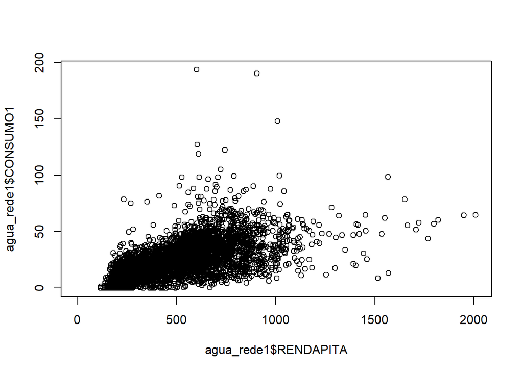

```r
plot(x = agua_rede1$RENDAPITA,
     y = agua_rede1$CONSUMO1)
```

É possível ainda aprimorar o diagrama de dispersão adicionando alguns argumentos:

- `xlab`: um rótulo para o eixo x
- `ylab`: um rótulo para o eixo y
- Para explorar mais opções, acesse a documentação da função `plot` executando o comando `help(plot)`

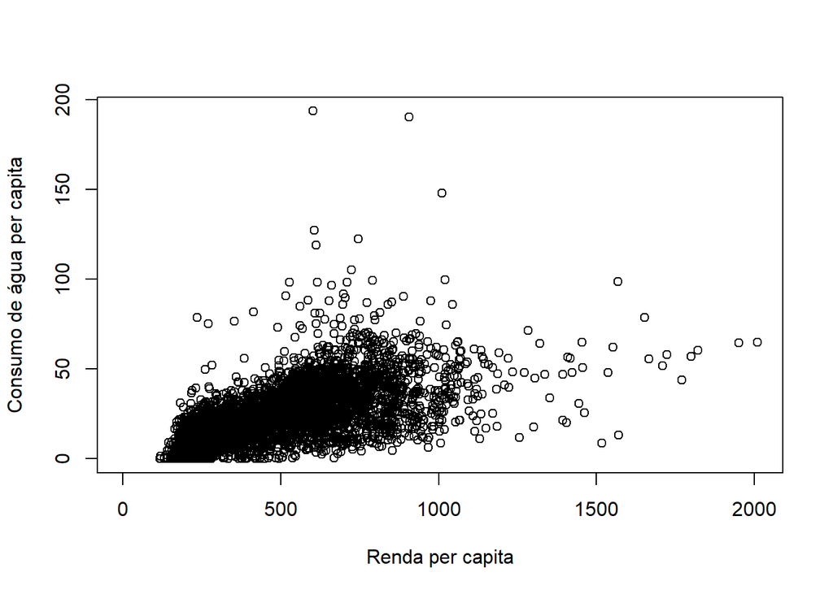

```r
plot(x = agua_rede1$RENDAPITA,
     y = agua_rede1$CONSUMO1,
     xlab = "Renda per capita",
     ylab = "Consumo de água per capita")
```

Também é possível criar um diagrama de dispersão com o pacote `ggplot2`.

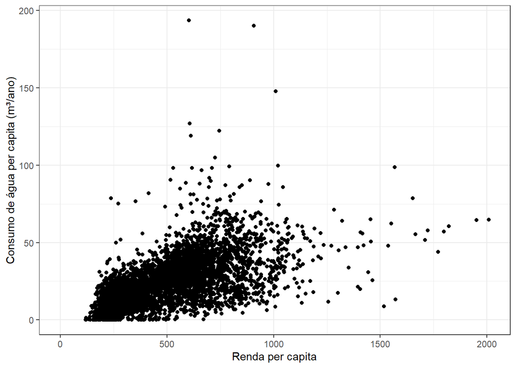

```r
ggplot(data = agua_rede1, aes(x = RENDAPITA, y = CONSUMO1)) +
  geom_point() +
  theme_bw() +
  xlab("Renda per capita") +
  ylab("Consumo de água per capita (m³/ano)")
```

O diagrama de dispersão indica que existe uma **correlação positiva** entre as duas variáveis, ou seja, **quanto maior a renda, maior o consumo de água**. Mas vamos verificar essa relação estatísticamente através de um teste de correlação.

# 3. Coeficiente de correlação

Um **coeficiente de correlação** é uma **medida padronizada do relacionamento entre duas variáveis**. O **coeficiente de correlação de Pearson** apresenta um valor entre -1 e 1, sendo que:

- -1 indica uma correlação negativa perfeita
- 0 indica a ausência de relacionamento linear
- 1 indica uma correlação positiva perfeita

Para calcular o coeficiente de correlação de Pearson entre duas variáveis usaremos a função `cor()`, definindo os argumentos:

- `x`: Renda per capita
- `y`: Consumo de Água per capita
- `method = "pearson"`: para calcular o coeficiente de correlação de Pearson (também é possível calcular coeficiente de correlação de Spearman e o Tau de Kendall)
- `use = "complete.obs"`: para remover os valores faltantes (NA)

```r
cor(x = agua_rede1$RENDAPITA,
    y = agua_rede1$CONSUMO1,
    method = "pearson",
    use = "complete.obs")
```

```
## [1] 0.6012537
```

A correlação entre a Renda e o Consumo de Água é de `0,6`, indicando a mesma **correlação positiva** que o gráfico de dispersão permitiu visualizar.

# 4. Teste de significância

Ainda é necessário confirmar se a correlação não se deve a um erro amostral, ou seja, ao acaso. Para isso vamos realizar um **teste de significância**.

Para testar a significâcia do coeficiente de correlação de Pearson é necessário executar a função `cor.test()`, especificando os argumentos:

- `x`: Renda per capita
- `y`: Consumo de Água per capita
- `method = "pearson"`: para calcular o coeficiente de correlação de Pearson
- `alternative = "two.sided"`: para teste de hipótese bilateral
- `conf.level = 0.95`: define o nível de significância como 0,05

```r
cor.test(x = agua_rede1$RENDAPITA,
         y = agua_rede1$CONSUMO1,
         method = "pearson",
         alternative = "two.sided",
         conf.level = 0.95)
```

```
##
##  Pearson's product-moment correlation
##
## data:  agua_rede1$RENDAPITA and agua_rede1$CONSUMO1
## t = 49.997, df = 4415, p-value < 2.2e-16
## alternative hypothesis: true correlation is not equal to 0
## 95 percent confidence interval:
##  0.5820832 0.6197561
## sample estimates:
##       cor
## 0.6012537
```

Como o p-valor (`0,00000000000000022`) é menor que o nível de significância (`0,05`), **rejeitamos a hipótese nula (H0)**, ou seja, os dados indicam que não é possível falsear a hipótese alternativa (H1), sendo uma evidência de que **pode existir uma correlação entre o Consumo de Água e a Renda**.

# 5. Matriz de correlação

Quando você estiver explorando a sua hipótese, com os dados do seu trabalho de curso, você pode achar necessário analisar a correlação entre várias duplas de variáveis.

Se esse for o caso, é indicada a construção de uma **matriz de correlação**, que permite a **análise e visualização simultânea da relação entre duas variáveis**.

Para construir uma matriz de correlação, primeiro é necessário selecionar as variáveis que deseja investigar (com a função `select()`), para depois calcular o coeficiente de correlação entre cada dupla de variáveis (com a função `cor()`).

```r
agua_rede1 %>%
  select(RENDAPITA, CONSUMO1, CONSUMO2, PIB, IDH, GINI, REDE, PROPREDE) %>%
  cor(method = "pearson",
    use = "complete.obs")
```

```
##            RENDAPITA   CONSUMO1    CONSUMO2        PIB        IDH        GINI
## RENDAPITA  1.0000000  0.6012537  0.49269163 0.22623371  0.7415117 -0.21476760
## CONSUMO1   0.6012537  1.0000000  0.85700512 0.11760770  0.5143510 -0.26802459
## CONSUMO2   0.4926916  0.8570051  1.00000000 0.06518107  0.4255431 -0.25814509
## PIB        0.2262337  0.1176077  0.06518107 1.00000000  0.1190256  0.09083846
## IDH        0.7415117  0.5143510  0.42554311 0.11902559  1.0000000 -0.32599859
## GINI      -0.2147676 -0.2680246 -0.25814509 0.09083846 -0.3259986  1.00000000
## REDE       0.2203883  0.1165290  0.05918231 0.95388403  0.1142680  0.10596453
## PROPREDE   0.4012507  0.6117510  0.35458719 0.11643021  0.3731320 -0.17370841
##                 REDE   PROPREDE
## RENDAPITA 0.22038826  0.4012507
## CONSUMO1  0.11652903  0.6117510
## CONSUMO2  0.05918231  0.3545872
## PIB       0.95388403  0.1164302
## IDH       0.11426803  0.3731320
## GINI      0.10596453 -0.1737084
## REDE      1.00000000  0.1343521
## PROPREDE  0.13435207  1.0000000
```

Se você quiser facilitar ainda mais a visualização da matriz de correlação, pode adicionar ainda a função `round()` para arredondar os valores do coeficiente de correlação para duas casas decimais.

```r
agua_rede1 %>%
  select(RENDAPITA, CONSUMO1, CONSUMO2, PIB, IDH, GINI, REDE, PROPREDE) %>%
  cor(method = "pearson",
    use = "complete.obs") %>%
  round(digits = 2)
```

```
##           RENDAPITA CONSUMO1 CONSUMO2  PIB   IDH  GINI REDE PROPREDE
## RENDAPITA      1.00     0.60     0.49 0.23  0.74 -0.21 0.22     0.40
## CONSUMO1       0.60     1.00     0.86 0.12  0.51 -0.27 0.12     0.61
## CONSUMO2       0.49     0.86     1.00 0.07  0.43 -0.26 0.06     0.35
## PIB            0.23     0.12     0.07 1.00  0.12  0.09 0.95     0.12
## IDH            0.74     0.51     0.43 0.12  1.00 -0.33 0.11     0.37
## GINI          -0.21    -0.27    -0.26 0.09 -0.33  1.00 0.11    -0.17
## REDE           0.22     0.12     0.06 0.95  0.11  0.11 1.00     0.13
## PROPREDE       0.40     0.61     0.35 0.12  0.37 -0.17 0.13     1.00
```

Também é possível visualizar a matriz de correlação construindo um gráfico, usando a função `corrplot()` do pacote `corrplot`.

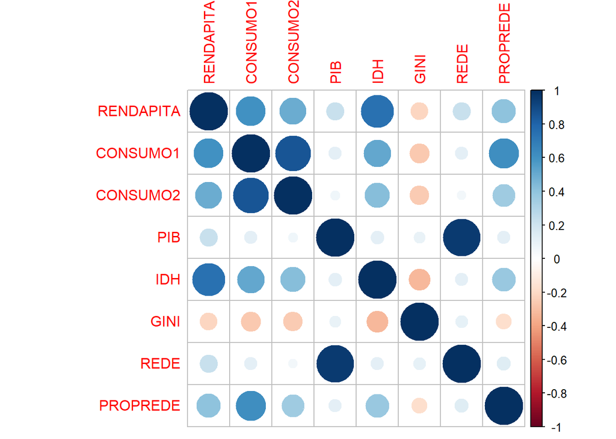

```r
agua_rede1 %>%
  select(RENDAPITA, CONSUMO1, CONSUMO2, PIB, IDH, GINI, REDE, PROPREDE) %>%
  cor(method = "pearson",
    use = "complete.obs") %>%
  corrplot()
```

Manipulando o argumento `method`, você pode testar outras visualizações desse gráfico, conforme indica a documentação da função (`help(corrplot)`) e os exemplos abaixo.

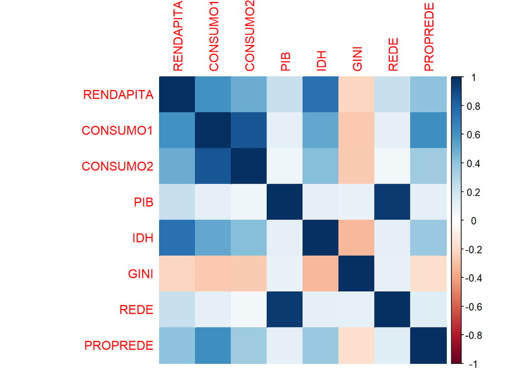

```r
agua_rede1 %>%
  select(RENDAPITA, CONSUMO1, CONSUMO2, PIB, IDH, GINI, REDE, PROPREDE) %>%
  cor(method = "pearson",
    use = "complete.obs") %>%
  corrplot(method = "color")
```

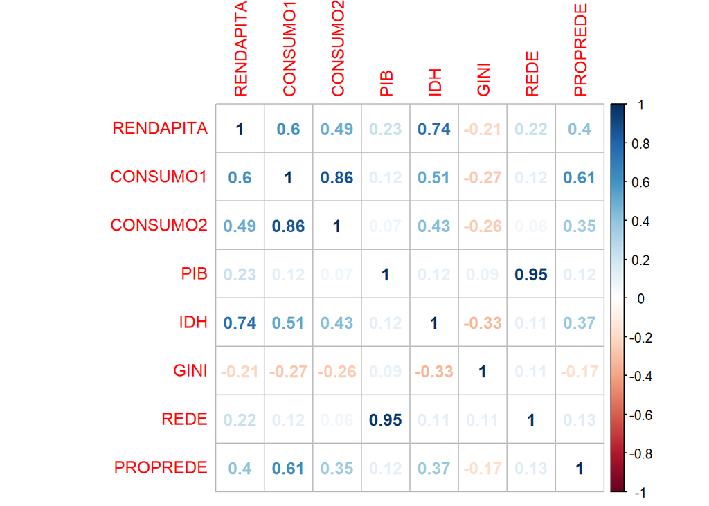

```r
agua_rede1 %>%
  select(RENDAPITA, CONSUMO1, CONSUMO2, PIB, IDH, GINI, REDE, PROPREDE) %>%
  cor(method = "pearson",
    use = "complete.obs") %>%
  corrplot(method = "number")
```

As abordagens propostas possuem a desvantagem de não computarem o teste de significância em conjunto com a correlação, ou seja, para saber se o resultado da correlação é significativo, seria necessário executar o teste de significância para cada dupla de variáveis com a função `cor.test()`.

Usando a função `rcorr()` é possível calcular uma matriz de correlação que é apresentada com uma matriz adicional que exibe o número de observações consideradas neste cômputo (após a exclusão de valores faltantes) e outra matriz adicional que exibe o nível de significância. Mas atenção: além de ser necessário aplicar a função `select()` para selecionar as variáveis numéricas de interesse, também é necessário transformar essa tabela em uma matriz com a função `as.matrix()`.

```r
agua_rede1 %>%
  select(RENDAPITA, CONSUMO1, CONSUMO2, PIB, IDH, GINI, REDE, PROPREDE) %>%
  as.matrix() %>%
  rcorr(type = "pearson")
```

```
##           RENDAPITA CONSUMO1 CONSUMO2  PIB   IDH  GINI REDE PROPREDE
## RENDAPITA      1.00     0.60     0.49 0.22  0.69 -0.28 0.21     0.42
## CONSUMO1       0.60     1.00     0.86 0.12  0.51 -0.27 0.12     0.61
## CONSUMO2       0.49     0.86     1.00 0.07  0.43 -0.26 0.06     0.35
## PIB            0.22     0.12     0.07 1.00  0.11  0.08 0.95     0.11
## IDH            0.69     0.51     0.43 0.11  1.00 -0.32 0.11     0.36
## GINI          -0.28    -0.27    -0.26 0.08 -0.32  1.00 0.09    -0.25
## REDE           0.21     0.12     0.06 0.95  0.11  0.09 1.00     0.12
## PROPREDE       0.42     0.61     0.35 0.11  0.36 -0.25 0.12     1.00
##
## n
##           RENDAPITA CONSUMO1 CONSUMO2  PIB  IDH GINI REDE PROPREDE
## RENDAPITA      5566     4417     4417 4939 4939 5566 5560     5560
## CONSUMO1       4417     4417     4417 4417 4417 4417 4417     4417
## CONSUMO2       4417     4417     4417 4417 4417 4417 4417     4417
## PIB            4939     4417     4417 4939 4939 4939 4939     4939
## IDH            4939     4417     4417 4939 4939 4939 4939     4939
## GINI           5566     4417     4417 4939 4939 5566 5560     5560
## REDE           5560     4417     4417 4939 4939 5560 5560     5560
## PROPREDE       5560     4417     4417 4939 4939 5560 5560     5560
##
## P
##           RENDAPITA CONSUMO1 CONSUMO2 PIB IDH GINI REDE PROPREDE
## RENDAPITA            0        0        0   0   0    0    0
## CONSUMO1   0                  0        0   0   0    0    0
## CONSUMO2   0         0                 0   0   0    0    0
## PIB        0         0        0            0   0    0    0
## IDH        0         0        0        0       0    0    0
## GINI       0         0        0        0   0        0    0
## REDE       0         0        0        0   0   0         0
## PROPREDE   0         0        0        0   0   0    0
```